# Analysis Of Titanic Dataset

## Introduction

On April 15, 1912, during her maiden voyage, the Titanic sank after colliding with an iceberg, killing 1502 out of 2224 passengers and crew. This sensational tragedy shocked the international community and led to better safety regulations for ships.

One of the reasons that the shipwreck led to such loss of life was that there were not enough lifeboats for the passengers and crew. Although there was some element of luck involved in surviving the sinking, some groups of people were more likely to survive than others, such as women, children, and the upper-class.

In this project I have applied various data analysis techniques to answer some questions related to survival of passengers.

### Questions

1-How many adults(above 18) survived?

2-Did Socio-Economic status have any effect on survival?

3-Did people who paid higher ticket fare have better survival rate?

4-Which port had most survivors?

5-What was the survival rate for children and senior citizens?

## Data Wrangling

```python
#import all necessary packages and functions
import pandas as pd
import numpy as np
import matplotlib.pyplot as plt
import seaborn as sns
%pylab inline

#read the csv file and display first few lines
data=pd.read_csv("titanic-data.csv")
data.head()
```

|  | PassengerId | Survived | Pclass | Name | Sex | Age | SibSp | Parch | Ticket | Fare | Cabin | Embarked |
| --- | --- | --- | --- | --- | --- | --- | --- | --- | --- | --- | --- | --- |
| 0 | 1 | 0 | 3 | Braund, Mr. Owen Harris | male | 22.0 | 1 | 0 | A/5 21171 | 7.2500 | NaN | S |
| 1 | 2 | 1 | 1 | Cumings, Mrs. John Bradley (Florence Briggs Th... | female | 38.0 | 1 | 0 | PC 17599 | 71.2833 | C85 | C |
| 2 | 3 | 1 | 3 | Heikkinen, Miss. Laina | female | 26.0 | 0 | 0 | STON/O2. 3101282 | 7.9250 | NaN | S |
| 3 | 4 | 1 | 1 | Futrelle, Mrs. Jacques Heath (Lily May Peel) | female | 35.0 | 1 | 0 | 113803 | 53.1000 | C123 | S |
| 4 | 5 | 0 | 3 | Allen, Mr. William Henry | male | 35.0 | 0 | 0 | 373450 | 8.0500 | NaN | S |

There are 12 variables in this dataset.The data description as per [Kaggle](https://www.kaggle.com/c/titanic/data) is as follows-

**Variable** **Definition** **Key**

*survival* Survival 0 = No, 1 = Yes

*pclass* Ticket class 1 = 1st, 2 = 2nd, 3 = 3rd

*sex* Sex

*Age* Age in years

*sibsp* # of siblings / spouses aboard the Titanic

*parch* # of parents / children aboard the Titanic

*ticket* Ticket number

*fare* Passenger fare

*cabin* Cabin number

*embarked* Port of Embarkation C = Cherbourg, Q = Queenstown, S = Southampton

**Variable Notes**

*pclass*: A proxy for socio-economic status (SES) 1st = Upper 2nd = Middle 3rd = Lower

*age*: Age is fractional if less than 1. If the age is estimated, is it in the form of xx.5

*sibsp*: The dataset defines family relations in this way... Sibling = brother, sister, stepbrother, stepsister Spouse = husband, wife (mistresses and fiancés were ignored)

*parch*: The dataset defines family relations in this way... Parent = mother, father Child = daughter, son, stepdaughter, stepson Some children travelled only with a nanny, therefore parch=0 for them.

The **datatypes** of each variable is shown below-

```python
#Datatype of each variable
data.dtypes
```

```
PassengerId      int64
Survived         int64
Pclass           int64
Name            object
Sex             object
Age            float64
SibSp            int64
Parch            int64
Ticket          object
Fare           float64
Cabin           object
Embarked        object
dtype: object
```

```python
#Check for Missing Values

def check(variable):
    print "Missing Values in {} - {}".format(variable,len(data[data[variable].isnull()]))
    return None

#Check Missing values for each and every variable

check("Survived")
check("Pclass")
check("Name")
check("Sex")
check("Age")
check("SibSp")
check("Parch")
check("Ticket")
check("Fare")
check("Cabin")
check("Embarked")
```

```
Missing Values in Survived - 0
Missing Values in Pclass - 0
Missing Values in Name - 0
Missing Values in Sex - 0
Missing Values in Age - 177
Missing Values in SibSp - 0
Missing Values in Parch - 0
Missing Values in Ticket - 0
Missing Values in Fare - 0
Missing Values in Cabin - 687
Missing Values in Embarked - 2
```

It is quite clear that *Age*,*Cabin* and *Embarked* have Missing Vales.The Missing values present in *Embarked* can be ignored because it is very less but the number of missing values in *Cabin* is very high and cannot be used to perform proper analysis.Since Age will be used to perform various analysis in this report hence I have created a new data frame containing details of only those passengers whose age is present in the dataset.I have used this datset wherever age was required for analysis and the rest of the time I have used the original dataset.

```python
#Creating Modified Dataset without missing values of Age
new_data=data[data["Age"].notnull()]
new_data.describe()

#data=original dataset
#new_data=modified dataset
#The modified dataset has 714 values for each variable.
```

|  | PassengerId | Survived | Pclass | Age | SibSp | Parch | Fare |
| --- | --- | --- | --- | --- | --- | --- | --- |
| count | 714.000000 | 714.000000 | 714.000000 | 714.000000 | 714.000000 | 714.000000 | 714.000000 |
| mean | 448.582633 | 0.406162 | 2.236695 | 29.699118 | 0.512605 | 0.431373 | 34.694514 |
| std | 259.119524 | 0.491460 | 0.838250 | 14.526497 | 0.929783 | 0.853289 | 52.918930 |
| min | 1.000000 | 0.000000 | 1.000000 | 0.420000 | 0.000000 | 0.000000 | 0.000000 |
| 25% | 222.250000 | 0.000000 | 1.000000 | 20.125000 | 0.000000 | 0.000000 | 8.050000 |
| 50% | 445.000000 | 0.000000 | 2.000000 | 28.000000 | 0.000000 | 0.000000 | 15.741700 |
| 75% | 677.750000 | 1.000000 | 3.000000 | 38.000000 | 1.000000 | 1.000000 | 33.375000 |
| max | 891.000000 | 1.000000 | 3.000000 | 80.000000 | 5.000000 | 6.000000 | 512.329200 |

# Exploratory Data Analysis

```python
#Printing results of basic & common statistics
data.describe()
```

|  | PassengerId | Survived | Pclass | Age | SibSp | Parch | Fare |
| --- | --- | --- | --- | --- | --- | --- | --- |
| count | 891.000000 | 891.000000 | 891.000000 | 714.000000 | 891.000000 | 891.000000 | 891.000000 |
| mean | 446.000000 | 0.383838 | 2.308642 | 29.699118 | 0.523008 | 0.381594 | 32.204208 |
| std | 257.353842 | 0.486592 | 0.836071 | 14.526497 | 1.102743 | 0.806057 | 49.693429 |
| min | 1.000000 | 0.000000 | 1.000000 | 0.420000 | 0.000000 | 0.000000 | 0.000000 |
| 25% | 223.500000 | 0.000000 | 2.000000 | 20.125000 | 0.000000 | 0.000000 | 7.910400 |
| 50% | 446.000000 | 0.000000 | 3.000000 | 28.000000 | 0.000000 | 0.000000 | 14.454200 |
| 75% | 668.500000 | 1.000000 | 3.000000 | 38.000000 | 1.000000 | 0.000000 | 31.000000 |
| max | 891.000000 | 1.000000 | 3.000000 | 80.000000 | 8.000000 | 6.000000 | 512.329200 |

```python
#Since 0 & 1 are used to represent survival hence I used sum() to find number of survivors
data["Survived"].sum()
```

```
342
```

```python
#Function to calculate percentage
def calc(value,total):
    per=float(value)/float(total)
    return (per * 100)
```

Out of 891 people only 342 survived which is about **38.38%** and the average age of those who survived was around **28**.

```python
#Average age of survivors
data[data["Survived"]==1]["Age"].mean()
```

```
28.343689655172415
```

### Question-1

How many adults (above 18 years) survived?

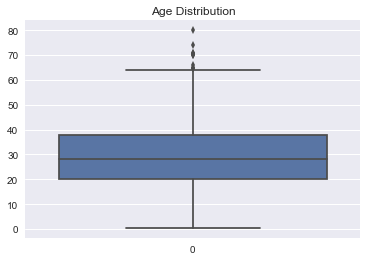

```python
#This Boxplot gives a basic idea about age distribution in the titanic dataset
sns.boxplot(data=new_data["Age"]).set_title("Age Distribution")
```

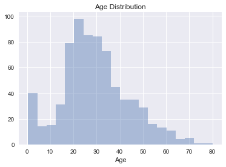

```python
#Another plot to properly understand Age distribution
sns.distplot(new_data["Age"],kde=False).set_title("Age Distribution")
```

```python
#Number of adults
adults=len(data[data["Age"]>18])
print "Number of Adults={}".format(adults)

#Number of adult survivors
adult_survivors=len(data[(data["Age"]>18) &(data["Survived"]==1)])
print "Number of Adult Survivors={}".format(adult_survivors)

#Pass to calc function which calculates percentage
print "Survival rate for adults={}".format(calc(adult_survivors,adults))
```

```
Number of Adults=575
Number of Adult Survivors=220
Survival rate for adults=38.2608695652
```

This clearly says that only **38.2 %** of adults survived.We can further tune this to find the number of male and female adults who survived.

```python
#Number of male adults who survived
adult_male_survivors=len(data[((data["Age"]>18) &(data["Survived"]==1) & (data["Sex"]=="male"))])
print "Number of adult males who survived={}".format(adult_male_survivors)

#Number of female adults who survived
adult_female_survivors=len(data[((data["Age"]>18) &(data["Survived"]==1) & (data["Sex"]=="female"))])
print "Number of adult females who survived={}".format(adult_female_survivors)
print "Survival rate for male adults={}".format(calc(adult_male_survivors,adult_survivors))
print "Survival rate for female adults={}".format(calc(adult_female_survivors,adult_survivors))
```

```
Number of adult males who survived=69
Number of adult females who survived=151
Survival rate for male adults=31.3636363636
Survival rate for female adults=68.6363636364
```

Thus out of 220 adults only **69** male adults survived which is around **31.36 %** and the rest were female adults i.e **68.63**

### Question-2

Did Socio-Economic status have any effect on survival?

There were three SES categories-

(a)Upper

(b)Middle

(c)Lower

Let's see how many of each SES category survived to make further conclusions

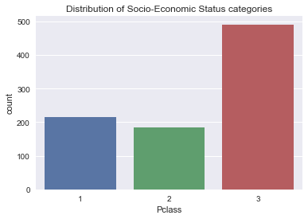

```python
#Bar Graph showing distribution of Upper,Middle and Lower Socio-Economic Status
sns.countplot(x=data["Pclass"]).set_title("Distribution of Socio-Economic Status categories")
```

```python
#Number of SES Passengers and their survival
#Upper class
upper_ses=len(data[data["Pclass"]==1 ])
print "Number of Upper Socio-Economic Status Passengers= {}".format(upper_ses)
upper_ses_survival=len(data[(data["Pclass"]==1) & (data["Survived"]==1)])
print "Number of Upper Socio-Economic Status Survivors= {}".format(upper_ses_survival)

#Middle class
middle_ses=len(data[data["Pclass"]==2])
print "Number of Middle Socio-Economic Status Passengers= {}".format(middle_ses)
middle_ses_survival=len(data[(data["Pclass"]==2) & (data["Survived"]==1)])
print "Number of Middle Socio-Economic Status Survivors= {}".format(middle_ses_survival)

#Lower class
lower_ses=len(data[data["Pclass"]==3])
print "Number of Lower Socio-Economic Status Passengers= {}".format(lower_ses)
lower_ses_survival=len(data[(data["Pclass"]==3) & (data["Survived"]==1)])
print "Number of Lower Socio-Economic Status Survivors= {}".format(lower_ses_survival)
```

```
Number of Upper Socio-Economic Status Passengers= 216
Number of Upper Socio-Economic Status Survivors= 136
Number of Middle Socio-Economic Status Passengers= 184
Number of Middle Socio-Economic Status Survivors= 87
Number of Lower Socio-Economic Status Passengers= 491
Number of Lower Socio-Economic Status Survivors= 119
```

From the above analysis we can conclude that the Upper Socio-Economic Status Passengers had best survival rate ( **62.96 %** ).Middle SES passengers had a survival rate of **47.28 %** and Lower SES passengers had lowest survival rate ( **24.23 %** ).

### Question-3

Did people who paid higher ticket fare than average ticket fare have better survival chances?

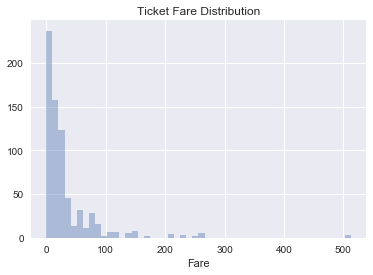

```python
#Distribution of Ticket Fare
sns.distplot(new_data["Fare"],kde=False).set_title("Ticket Fare Distribution")
```

```python
fare_mean=data["Fare"].mean()
total_aboveav=len(data[(data["Fare"]>fare_mean)])
total_aboveav_survivors=len(data[(data["Fare"]>fare_mean) & (data["Survived"]==1)])
print "Survival rate for people who paid higher ticket fare {} %".format(calc(total_aboveav_survivors,total_aboveav))
print "Average Ticket Fare={}".format(fare_mean)
```

```
Survival rate for people who paid higher ticket fare 59.7156398104 %
Average Ticket Fare=32.2042079686
```

We can conclude that people who paid higher ticket fare had better survival rate because they were mostly from Upper Social Economic Status Category.

# Question 4

Which port had most number of survivors?

There were 3 ports of embarkment

C = Cherbourg, Q = Queenstown, S = Southampton

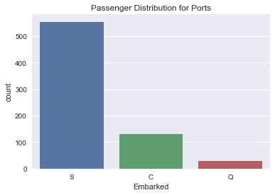

```python
#Plot showing number of passengers from each port
sns.countplot(new_data["Embarked"]).set_title("Passenger Distribution for Ports")
```

```python
#Number of Passengers for each port
southampton=len(data[data["Embarked"]=="S"])
print "Number of Passengers from Southampton={}".format(southampton)
southampton_survivors=len(data[(data["Embarked"]=="S") & (data["Survived"]==1)])
print "Number of Survivors from Southampton={}".format(southampton_survivors)

cherbourg=len(data[data["Embarked"]=="C"])
print "Number of Passengers from Cherbourg={}".format(cherbourg)
cherbourg_survivors=len(data[(data["Embarked"]=="C") & (data["Survived"]==1)])
print "Number of Survivors from Cherbourg={}".format(cherbourg_survivors)

queenstown=len(data[data["Embarked"]=="Q"])
print "Number of Passengers from Queenstown={}".format(queenstown)
queenstown_survivors=len(data[(data["Embarked"]=="Q") & (data["Survived"]==1)])
print "Number of Survivors from Queenstown={}".format(queenstown_survivors)

print "{} % Passengers survived from Southampton".format(calc(southampton_survivors,southampton))
print "{} % Passengers survived from Cherbourg".format(calc(cherbourg_survivors,cherbourg))
print "{} % Passengers survived from Queenstown".format(calc(queenstown_survivors,queenstown))
```

```
Number of Passengers from Southampton=644
Number of Survivors from Southampton=217
Number of Passengers from Cherbourg=168
Number of Survivors from Cherbourg=93
Number of Passengers from Queenstown=77
Number of Survivors from Queenstown=30
33.6956521739 % Passengers survived from Southampton
55.3571428571 % Passengers survived from Cherbourg
38.961038961 % Passengers survived from Queenstown
```

```python
#Reason for higher survival rate
upper_cherbourg=len(data[(data["Embarked"]=="C") & (data["Pclass"]==1) ])
print upper_cherbourg
```

```
85
```

Survival rate for Cherbourg port was highest because it had higher number of Upper social economic status category passengers (85/168).

### Question 5

What was the survival rate for children and senior citizens?

Let's consider the age for children as below 14 years and above 60 for senior citizens.

```python
#Survival rate for children
children=len(data[data["Age"]<14])
children_survived=len(data[(data["Age"]<14) & (data["Survived"]==1)])
print "Survival Rate for Children={}".format(calc(children_survived,children))

#Survival rate for senior citizens
senior_citizens=len(data[data["Age"]>60])
senior_citizens_survived=len(data[(data["Age"]>60) & (data["Survived"]==1)])
print "Survival Rate for Senior Citizens={}".format(calc(senior_citizens_survived,senior_citizens))

#Number of male senior citizens who survived
msenior_citizens_survived=len(data[(data["Age"]>60) & (data["Sex"]=="male") &(data["Survived"]==1)])
print "Number of male senior citizens who survived={}".format(msenior_citizens_survived)
```

```
Survival Rate for Children=59.1549295775
Survival Rate for Senior Citizens=22.7272727273
Number of male senior citizens who survived=2
```

# Conclusions

According to this analysis, Women (above 18) and children (below 14) had higher survival rates than men and senior citizens.The most surprising fact was that there were only **two** male senior citizens who survived.The passengers who started their journey from Cherbourg port had best survival rates among all the other ports.Another fact that comes out from this analysis is that people who had lower economic status had only around **24%** chance of survival.

### Limitations

1-There were missing values for variables like *Age*,*Embarked* and *Cabin*.The *Cabin* variable cannot be used to perform proper analysis because around 75% of the values are missing.*Embarked* had only 2 missing values so it didn't affect my analysis.*Age* too had 177 missing values,so I created a new dataset removing all the missing values.Thus, the results could have been slightly different if Age had all values present.

2-The dataset used just represents a small sample from the actual population.This datset has only 891 records whereas there were 2224 people on the Titanic.So the analysis performed could have resulted in slightly different results if performed on actual population.

# References

https://www.kaggle.com/c/titanic/data

https://elitedatascience.com/python-seaborn-tutorial